# Exploratory Data Analysis of White Wine Quality Dataset by Swaranika

```
## 'data.frame':    4898 obs. of  13 variables:
##  $ X                   : int  1 2 3 4 5 6 7 8 9 10 ...
##  $ fixed.acidity       : num  7 6.3 8.1 7.2 7.2 8.1 6.2 7 6.3 8.1 ...
##  $ volatile.acidity    : num  0.27 0.3 0.28 0.23 0.23 0.28 0.32 0.27 0.3 0.22 ...
##  $ citric.acid         : num  0.36 0.34 0.4 0.32 0.32 0.4 0.16 0.36 0.34 0.43 ...
##  $ residual.sugar      : num  20.7 1.6 6.9 8.5 8.5 6.9 7 20.7 1.6 1.5 ...
##  $ chlorides           : num  0.045 0.049 0.05 0.058 0.058 0.05 0.045 0.045 0.049 0.044 ...
##  $ free.sulfur.dioxide : num  45 14 30 47 47 30 30 45 14 28 ...
##  $ total.sulfur.dioxide: num  170 132 97 186 186 97 136 170 132 129 ...
##  $ density             : num  1.001 0.994 0.995 0.996 0.996 ...
##  $ pH                  : num  3 3.3 3.26 3.19 3.19 3.26 3.18 3 3.3 3.22 ...
##  $ sulphates           : num  0.45 0.49 0.44 0.4 0.4 0.44 0.47 0.45 0.49 0.45 ...
##  $ alcohol             : num  8.8 9.5 10.1 9.9 9.9 10.1 9.6 8.8 9.5 11 ...
##  $ quality             : int  6 6 6 6 6 6 6 6 6 6 ...
```

We can observe that all of the variables are numbers and there exist no factor type in the dataset.

A statistical summary of the data is given below:

```
##        X        fixed.acidity    volatile.acidity  citric.acid
##  Min.   :   1   Min.   : 3.800   Min.   :0.0800   Min.   :0.0000
##  1st Qu.:1225   1st Qu.: 6.300   1st Qu.:0.2100   1st Qu.:0.2700
##  Median :2450   Median : 6.800   Median :0.2600   Median :0.3200
##  Mean   :2450   Mean   : 6.855   Mean   :0.2782   Mean   :0.3342
##  3rd Qu.:3674   3rd Qu.: 7.300   3rd Qu.:0.3200   3rd Qu.:0.3900
##  Max.   :4898   Max.   :14.200   Max.   :1.1000   Max.   :1.6600
##  residual.sugar     chlorides       free.sulfur.dioxide
##  Min.   : 0.600   Min.   :0.00900   Min.   :  2.00
##  1st Qu.: 1.700   1st Qu.:0.03600   1st Qu.: 23.00
##  Median : 5.200   Median :0.04300   Median : 34.00
##  Mean   : 6.391   Mean   :0.04577   Mean   : 35.31
##  3rd Qu.: 9.900   3rd Qu.:0.05000   3rd Qu.: 46.00
##  Max.   :65.800   Max.   :0.34600   Max.   :289.00
##  total.sulfur.dioxide    density             pH          sulphates
##  Min.   :  9.0        Min.   :0.9871   Min.   :2.720   Min.   :0.2200
##  1st Qu.:108.0        1st Qu.:0.9917   1st Qu.:3.090   1st Qu.:0.4100
##  Median :134.0        Median :0.9937   Median :3.180   Median :0.4700
##  Mean   :138.4        Mean   :0.9940   Mean   :3.188   Mean   :0.4898
##  3rd Qu.:167.0        3rd Qu.:0.9961   3rd Qu.:3.280   3rd Qu.:0.5500
##  Max.   :440.0        Max.   :1.0390   Max.   :3.820   Max.   :1.0800
##     alcohol         quality
##  Min.   : 8.00   Min.   :3.000
##  1st Qu.: 9.50   1st Qu.:5.000
##  Median :10.40   Median :6.000
##  Mean   :10.51   Mean   :5.878
##  3rd Qu.:11.40   3rd Qu.:6.000
##  Max.   :14.20   Max.   :9.000
```

Quality values are between 3 and 9. Median and Mean is very close to each other which means the distribution is not so-skewed.

# Test Dataset Information:

In this project , we will explore’White Wine Quality’ dataset which was among the tidy dataset containing 4898 white wines with 11 variables on quantifying the chemical properties of each wine.At least 3 wine experts rated the quality of each wine, providing a rating between 0 (very bad) and 10 (very excellent).

The following information was given as part of project which contains basic information about units and a short description of each variable: ##Input variables (based on physicochemical tests):

1. fixed acidity: most acids involved with wine or fixed or nonvolatile (do not evaporate readily) (tartaric acid - g / dm<sup>3</sup>)
2. volatile acidity: the amount of acetic acid in wine, which at too high of levels can lead to an unpleasant, vinegar taste. (acetic acid - g / dm<sup>3</sup>)
3. citric acid: found in small quantities, citric acid can add ‘freshness’ and flavor to wines. (g / dm<sup>3</sup>)
4. residual sugar: the amount of sugar remaining after fermentation stops, it’s rare to find wines with less than 1 gram/liter and wines with greater than 45 grams/liter are considered sweet. (g / dm<sup>3</sup>)
5. chlorides: the amount of salt in the wine. (sodium chloride - g / dm<sup>3</sup>)
6. free sulfur dioxide: the free form of SO2 exists in equilibrium between molecular SO2 (as a dissolved gas) and bisulfite ion; it prevents microbial growth and the oxidation of wine. (mg / dm<sup>3</sup>)
7. total sulfur dioxide: amount of free and bound forms of S02; in low concentrations, SO2 is mostly undetectable in wine, but at free SO2 concentrations over 50 ppm, SO2 becomes evident in the nose and taste of wine. (mg / dm<sup>3</sup>)
8. density: the density of water is close to that of water depending on the percent alcohol and sugar content. (g / cm<sup>3</sup>)
9. pH: describes how acidic or basic a wine is on a scale from 0 (very acidic) to 14 (very basic); most wines are between 3-4 on the pH scale.
10. sulphates: a wine additive which can contribute to sulfur dioxide gas (S02) levels, wich acts as an antimicrobial and antioxidant. (potassium sulphate - g / dm<sup>3</sup>)
11. alcohol: the percent alcohol content of the wine. (% by volume)

## Output variable (based on sensory data):

12. quality (score between 0 and 10)

Also we can see that the quality variable of this data set is uneven , ie there are more mid-quality wines in this data set than low or high quality wine

The names of all of the variables in the test dataframe are as follows:

```
##  [1] "X"                    "fixed.acidity"        "volatile.acidity"
##  [4] "citric.acid"          "residual.sugar"       "chlorides"
##  [7] "free.sulfur.dioxide"  "total.sulfur.dioxide" "density"
## [10] "pH"                   "sulphates"            "alcohol"
## [13] "quality"
```

We can drop the ‘X’ column from further consideration as it is just a counterof the wine datadaset.

# Univariate Plots Section

To begin with, we will draw few histograms to get an overview of the distribution of the data. We can start with the Quality distribution

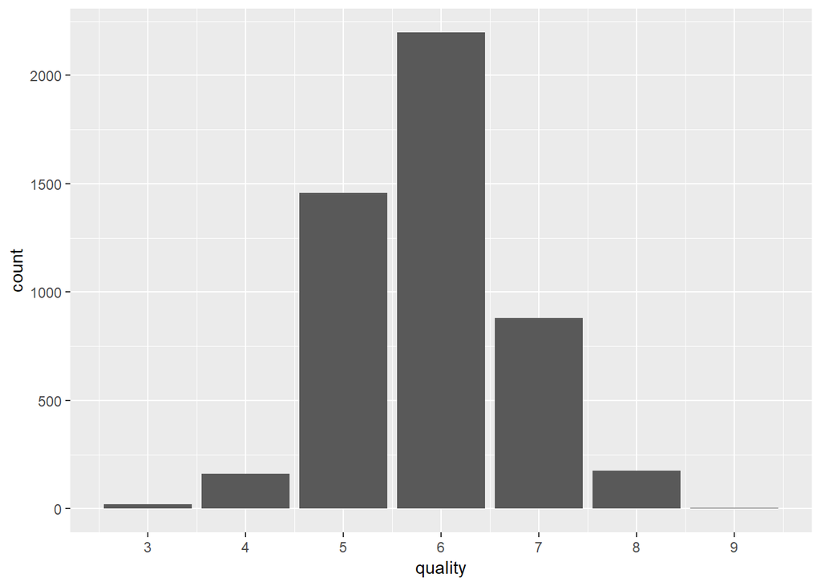

Here we can see that the distribution of the quality data looks normal.The lowest quality in the dataset is 3, while our highest is 9. There are more than 2000 observations (which is almost half of the dataset) for wines with a quality of 6. There are also some wines with low (rating is between 3 and 4) as well as there are medium (rating between 5 to 7), and of course high ( rating between 8 to 9). The bucketing of the wine quality will be helpful in our further analysis.

```
##  low  mid high
##  183 4535  180
```

There are multivariable attributes which we will be used for drawing histograms, so for reusablity purpose, creating a function is the best choice.This function will take three variables

We will draw histogram first on volatile acidity now.

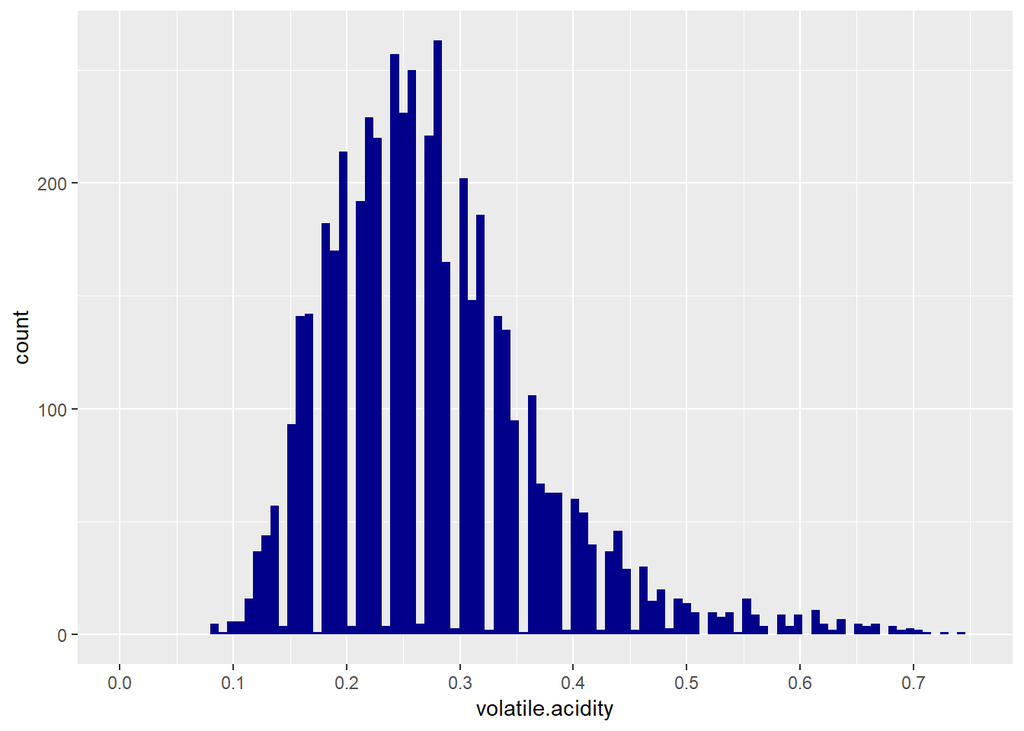

From the plots, we observe that the distribution is normal and also we can see the incremental small frequencies.

Next we will draw histogram on fixed.acidity distribution

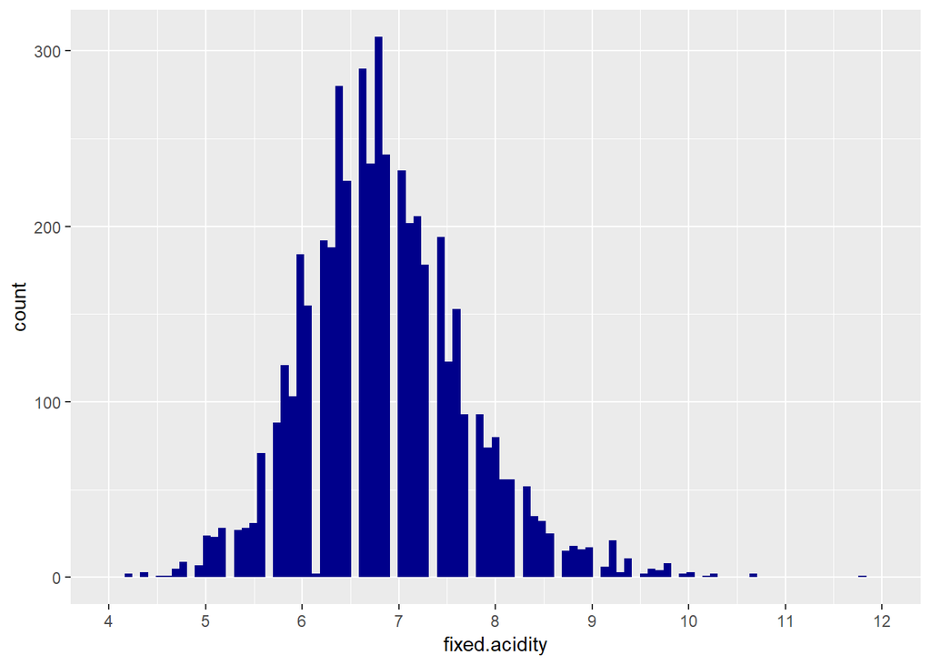

This distribution looks same like the volatile one , it is normal and there are incremental gaps in the distribution.

Next we will focus on citric acidity

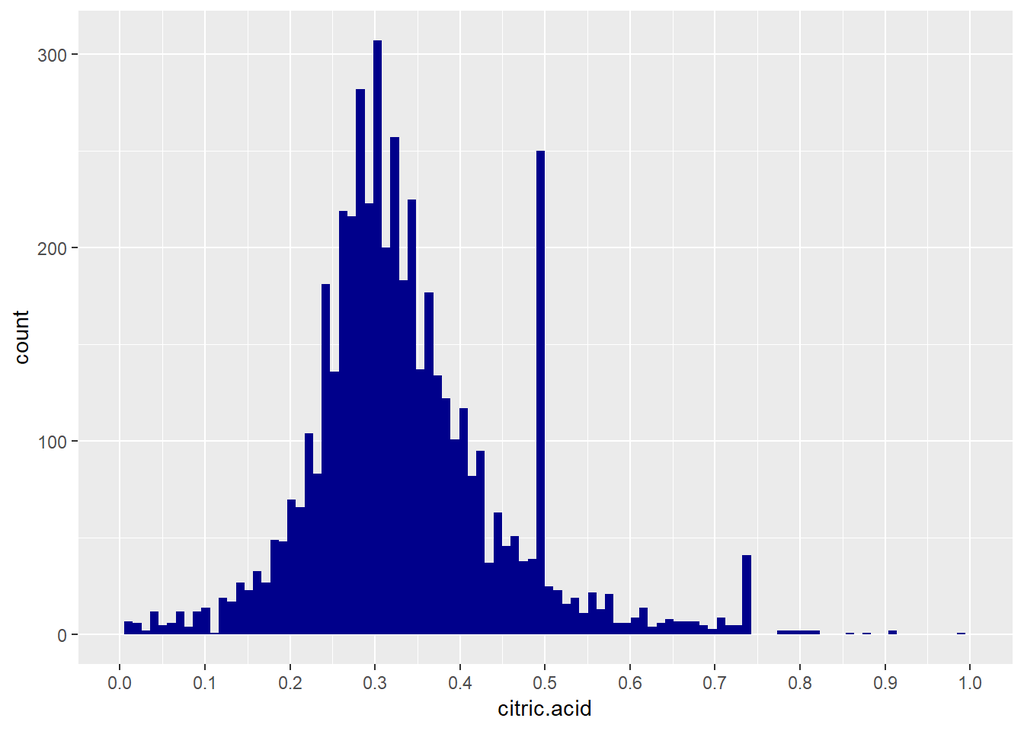

```
##    Min. 1st Qu.  Median    Mean 3rd Qu.    Max.
##  0.0000  0.2700  0.3200  0.3342  0.3900  1.6600
```

Apart from the aprroax normal distribution , we have also observed from the summary that the distribution has median of 0.32 and also mean of 0.3342.One more interesting observation from the histogram is that here is a second peak at around 0.5.

Next attribute is the residual sugar in the winequality dataset:

```
##    Min. 1st Qu.  Median    Mean 3rd Qu.    Max.
##   0.600   1.700   5.200   6.391   9.900  65.800
```

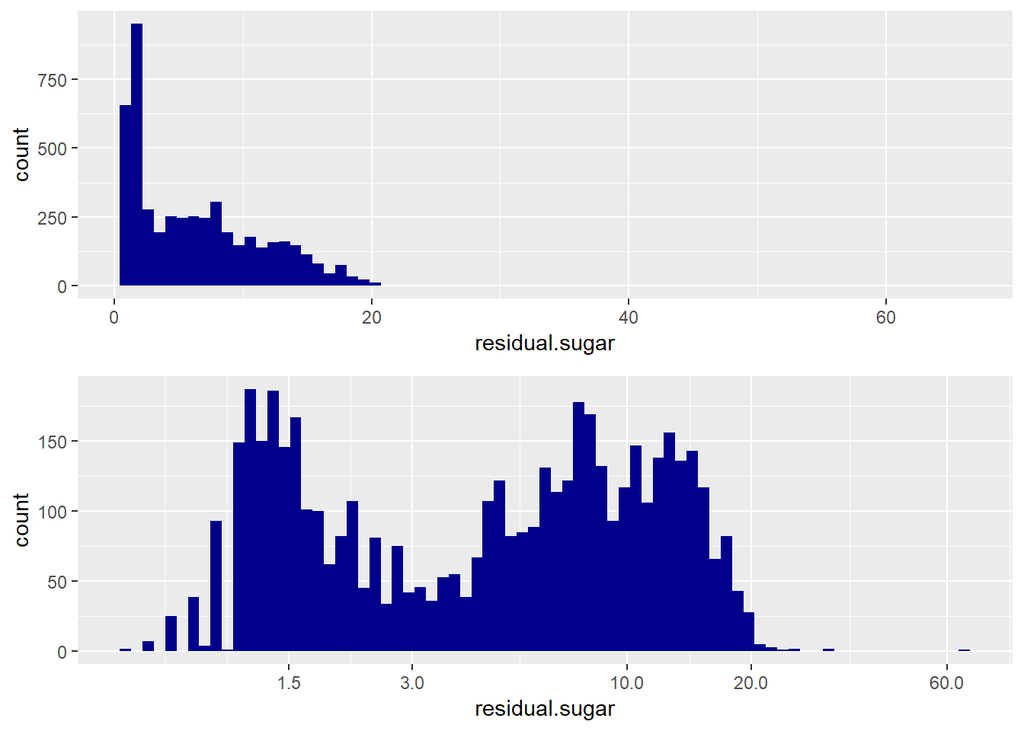

We can see from the residual sugar distribution that it is heavily skewed.Also from the logarithmic distribution , we can see that the distribution is bimodal with peaks at around 1g and 9g of sugar.

Chloride Distribution:

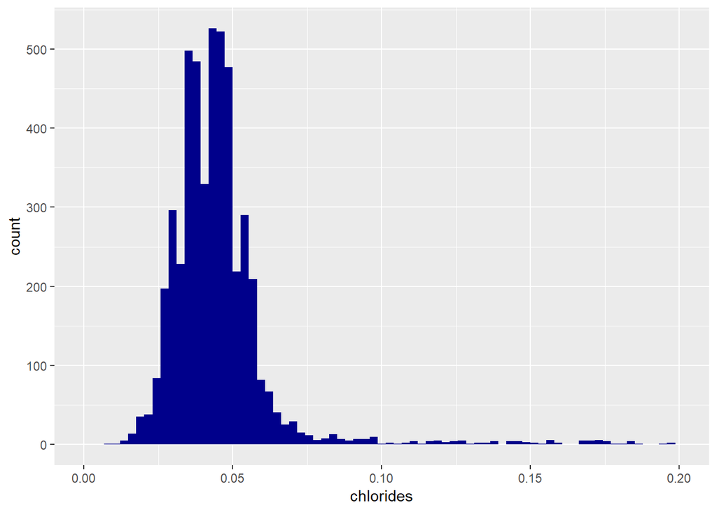

```
##    Min. 1st Qu.  Median    Mean 3rd Qu.    Max.
## 0.00900 0.03600 0.04300 0.04577 0.05000 0.34600
```

Chloride distribution for our wine data also looks about normal. We have a median of 0.043 and a mean of 0.04577.Also we can see that there are some outliers observed in this distribution. To further analysis of these outliners, I have used different plots.

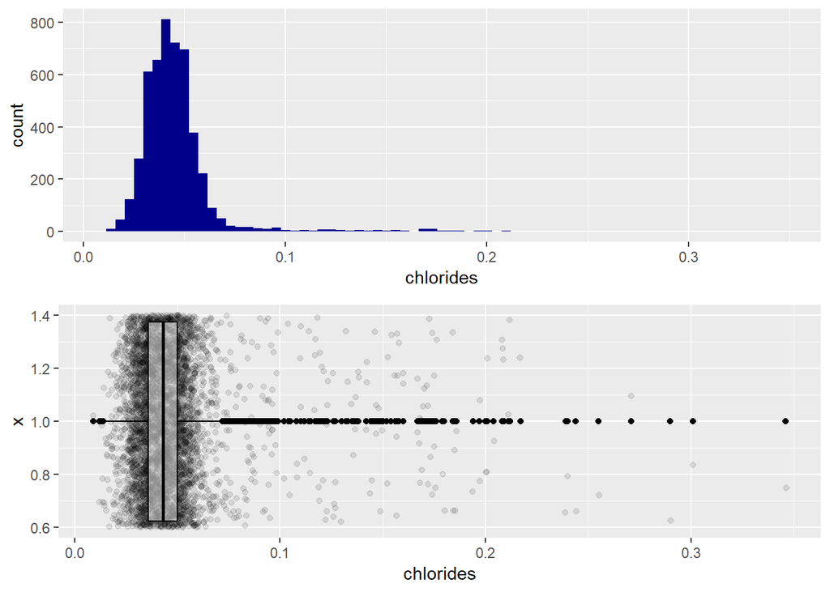

The boxplot depicts the narrowness of chlorides data distribution compared to the outlier distances.

Next we will explore free.sulfur.dioxide and total.sulfur.dioxide from the white wine dataset

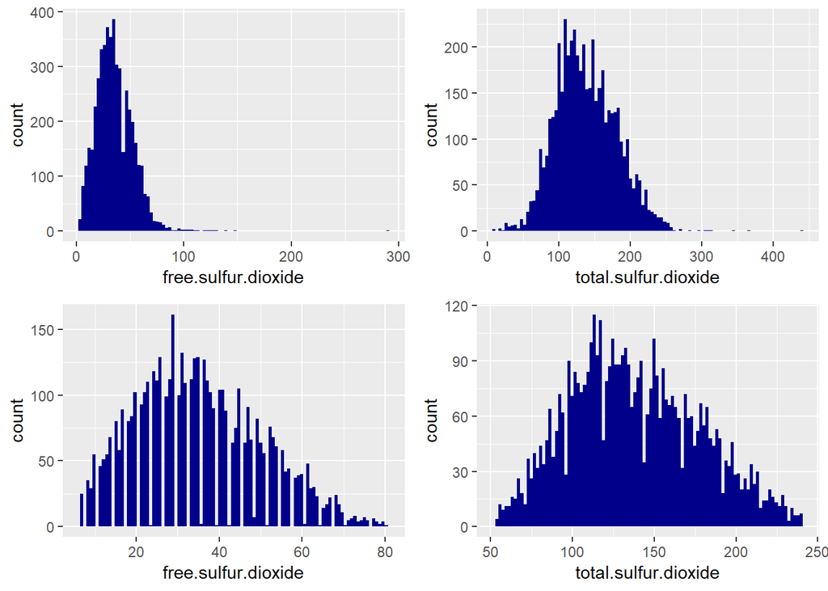

```
##    Min. 1st Qu.  Median    Mean 3rd Qu.    Max.
##    2.00   23.00   34.00   35.31   46.00  289.00
```

```
##    Min. 1st Qu.  Median    Mean 3rd Qu.    Max.
##     9.0   108.0   134.0   138.4   167.0   440.0
```

From the summary data, we can see that free sulfur dioxide distribution has a mean of 35.31, median of 34.00. The total sulfur dioxide distribution has a mean of 138.4 ,median of 134.0. In both cases the mean is larger than the median.

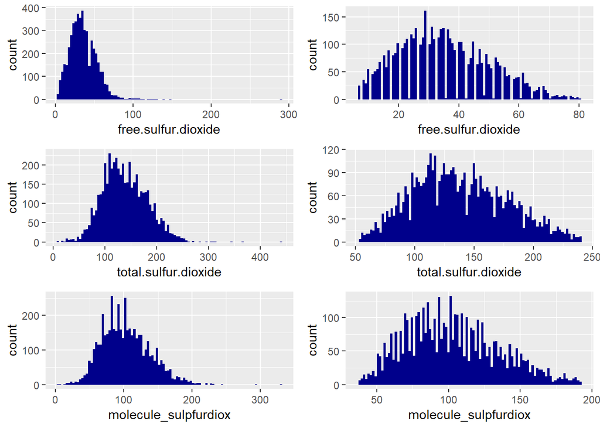

```
##    Min. 1st Qu.  Median    Mean 3rd Qu.    Max.
##     4.0    78.0   100.0   103.1   125.0   331.0
```

The graph of the new variable is similar to the total and free sulfur dioxide distribution. it is Nnrmal distribution with a slight longer right tail. It has a median of 100.0 and a mean of 103.1.

Next attribute is Density:

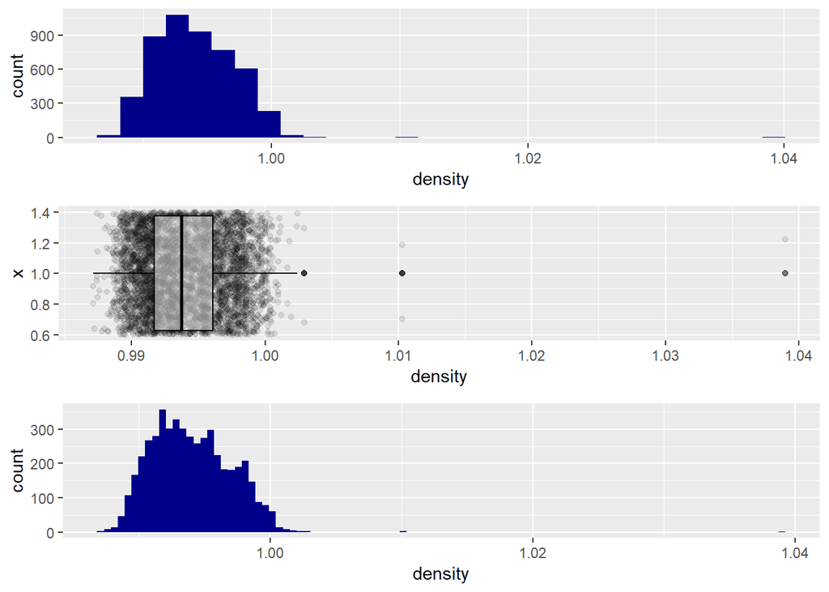

```
##    Min. 1st Qu.  Median    Mean 3rd Qu.    Max.
##  0.9871  0.9917  0.9937  0.9940  0.9961  1.0390
```

The density data distribution of white wine quality dataset is approximately normal in the firstplot. The distribution has median of 0.9937 and mean of 0.994.The distribution has a longer right tail than left tail more prominent in the first and third distribution.

Next attribute we will focus on pH value:

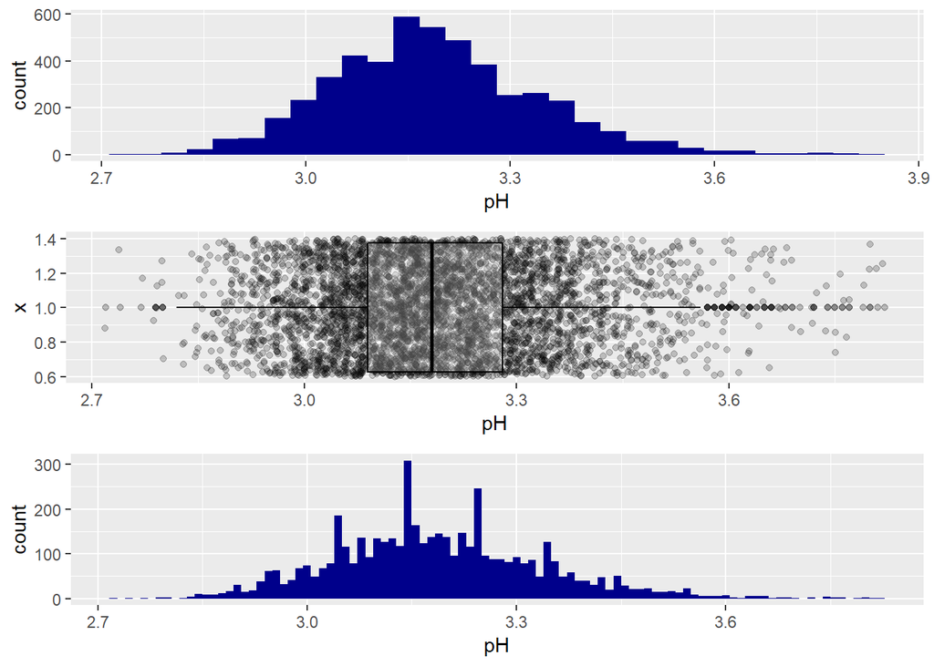

```
##    Min. 1st Qu.  Median    Mean 3rd Qu.    Max.
##   2.720   3.090   3.180   3.188   3.280   3.820
```

The pH distribution appears normal with slight longer right tail.The distribution has mean of 3.188 and median of 3.180.

Next we will explore Sulphates

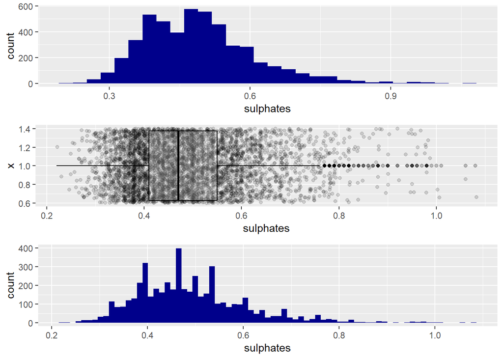

```
##    Min. 1st Qu.  Median    Mean 3rd Qu.    Max.
##  0.2200  0.4100  0.4700  0.4898  0.5500  1.0800
```

The sulphate distribution is approax normal,median of 0.4700 and mean of 0.4898.

Then we will move to final input variable of white wine quality dataset ie alcohol distribution.

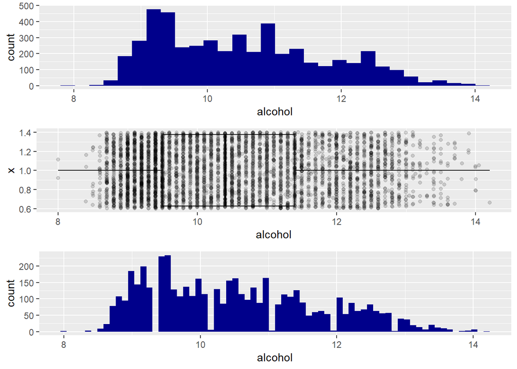

```
##    Min. 1st Qu.  Median    Mean 3rd Qu.    Max.
##    8.00    9.50   10.40   10.51   11.40   14.20
```

The allcohol distribution plot is approximately normal with slightly longer right tail, it has a median of 10.4, and a mean of 10.51.

# Univariate Analysis

Now we can summarize here what we have observed so far for the univariate distribution of different attributes and their analysis which can be useful for the next level analysis.

### What is the structure of your dataset?

There are 4,800 samples of white wine in this dataset.Each sample represents a white wine and that white wine has 11 attributes -fixed acidity, volatile acidity,citric acid, residual sugar, chlorides, free sulfur dioxide, total sulfur dioxide, density, pH, sulphates, alcohol and 1 output variable -white wine quality. All of the predictor variables are numerical and continuous values. The indicator value, quality, is a discrete and ordinal variable. All of the features are mostly normally distributed with some exception - some are little skewed and also few have some long tails. For Residual sugar , we have observed some serious outliers.

### What is/are the main feature(s) of interest in your dataset?

I think the main features of the data are quality(white wine), alcohol, some measure of acidity and acidity. The wine quality is dependent on not single attribute rather its the interaction of more than one attribute.

### What other features in the dataset do you think will help support your into your feature(s) of interest?

Free and total sulfur dioxide, sulphates, residual sugar and some measure of the acidity of the wine can be interesting to look at.

### Did you create any new variables from existing variables in the dataset?

Yes ,I have created one variable of buckets for wine quality- quality.bucket(low, med, high). The reason behind this because while we will be move on to the next level of analysis , this will be helpful to look at the trends to concentrate on low and high quality wines.Also I have created one more variable named molecule_sulpfurdiox, which is the difference between total sulfur dioxide and free sulfur dioxide.

### Of the features you investigated, were there any unusual distributions? you perform any operations on the data to tidy, adjust, or change the form the data? If so, why did you do this?

Among the attributes,Residual sugar is heavily skewed, so apart from the normal plot I have also plotted the logarithmic transformation of the data and able to see bimodal distribution of the data. The reason behind plotting the log distribution is to analyze and understand the residual sugar data better.As we have observed the peaks in discrete spots, it was difficult to understand the long distribution. Also there are a lot of slightly skewed normal distributions but Ihave just omitted the top 1% and bottom 1%.

# Bivariate Plots Section

Now we will move on to the Bivariate analysis where we will explore the relationship between the various parameters. First we can create a scatterplot matrix and will summarize the correlation coefficients.

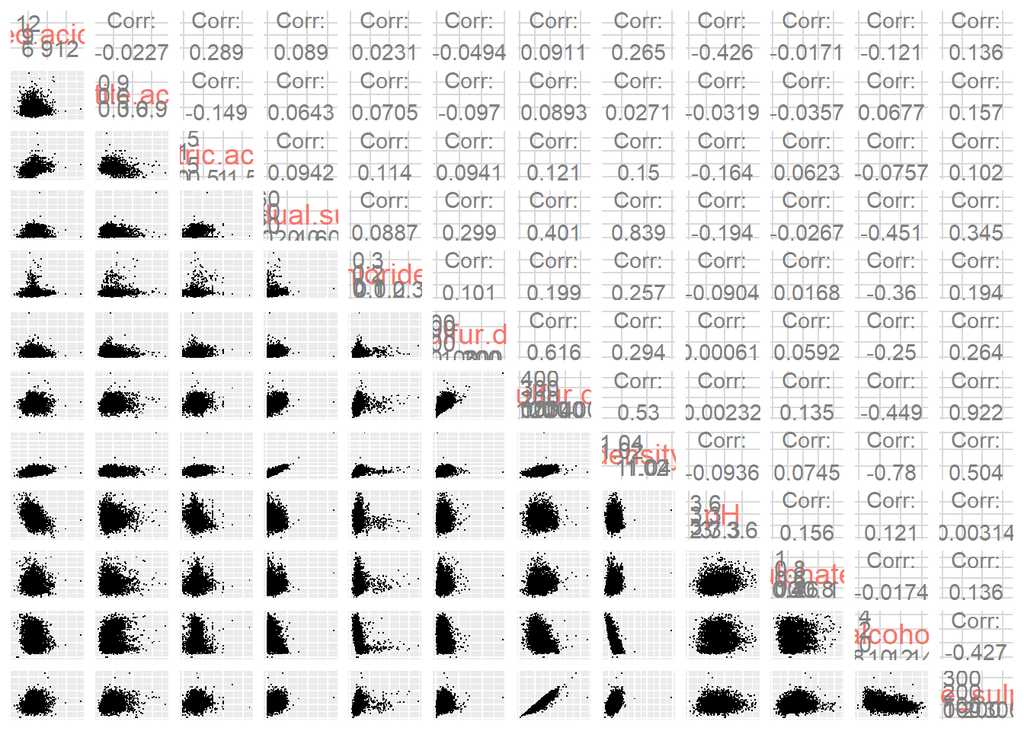

We can see that there are a handful number of plots which have similar shapes.It can be possible because of the test dataset and its range which is quite small.If we elaborately see the plots , we will understand that the correlations are justified.For example, the relationship between free sulfur dioxide and total sulfur dioxide, relationship between fixed acidity and pH are justified.

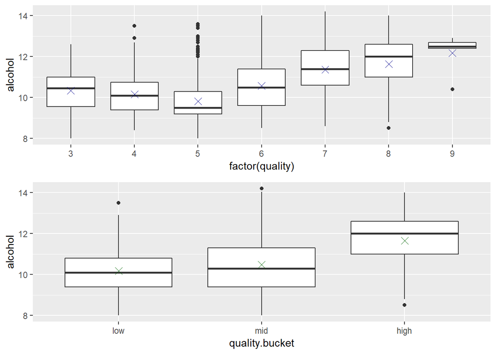

# Documenting the summary with the alcohol content greater than its mean (calculated earlier as 10.51)

```
##    Min. 1st Qu.  Median    Mean 3rd Qu.    Max.
##    8.00    9.50   10.40   10.51   11.40   14.20
```

```
## quality.bucket: low
##    Min. 1st Qu.  Median    Mean 3rd Qu.    Max.
##    8.00    9.40   10.10   10.17   10.80   13.50
## --------------------------------------------------------
## quality.bucket: mid
##    Min. 1st Qu.  Median    Mean 3rd Qu.    Max.
##    8.00    9.40   10.30   10.48   11.30   14.20
## --------------------------------------------------------
## quality.bucket: high
##    Min. 1st Qu.  Median    Mean 3rd Qu.    Max.
##    8.50   11.00   12.00   11.65   12.60   14.00
```

```
## quality: 3
##    Min. 1st Qu.  Median    Mean 3rd Qu.    Max.
##    8.00    9.55   10.45   10.35   11.00   12.60
## --------------------------------------------------------
## quality: 4
##    Min. 1st Qu.  Median    Mean 3rd Qu.    Max.
##    8.40    9.40   10.10   10.15   10.75   13.50
## --------------------------------------------------------
## quality: 5
##    Min. 1st Qu.  Median    Mean 3rd Qu.    Max.
##   8.000   9.200   9.500   9.809  10.300  13.600
## --------------------------------------------------------
## quality: 6
##    Min. 1st Qu.  Median    Mean 3rd Qu.    Max.
##    8.50    9.60   10.50   10.58   11.40   14.00
## --------------------------------------------------------
## quality: 7
##    Min. 1st Qu.  Median    Mean 3rd Qu.    Max.
##    8.60   10.60   11.40   11.37   12.30   14.20
## --------------------------------------------------------
## quality: 8
##    Min. 1st Qu.  Median    Mean 3rd Qu.    Max.
##    8.50   11.00   12.00   11.64   12.60   14.00
## --------------------------------------------------------
## quality: 9
##    Min. 1st Qu.  Median    Mean 3rd Qu.    Max.
##   10.40   12.40   12.50   12.18   12.70   12.90
```

```
##    Mode   FALSE    TRUE
## logical      34     146
```

```
##    Mode   FALSE    TRUE
## logical      55     128
```

From the above summary, we can see that aproximately more than 80% of high quality wines have alcohol values bigger than the mean. Also almost more than half of low quality wines have alcohol values smaller than the mean.

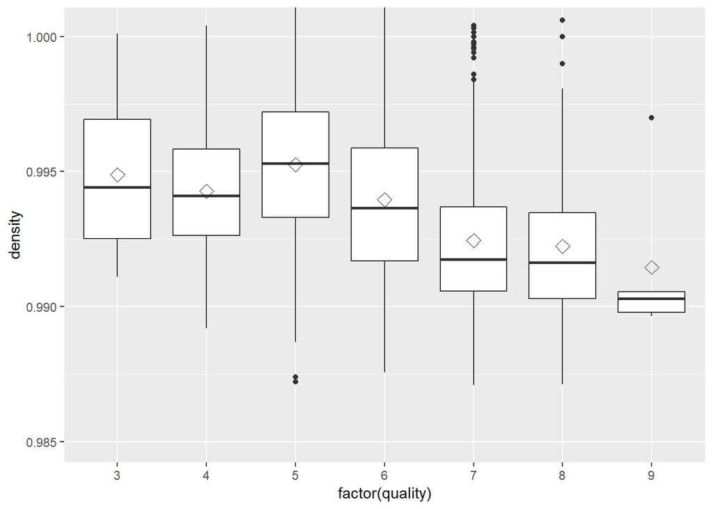

Next we will move on to the chlorides and plot this with quality of wine and also calculate a summary of them as well:

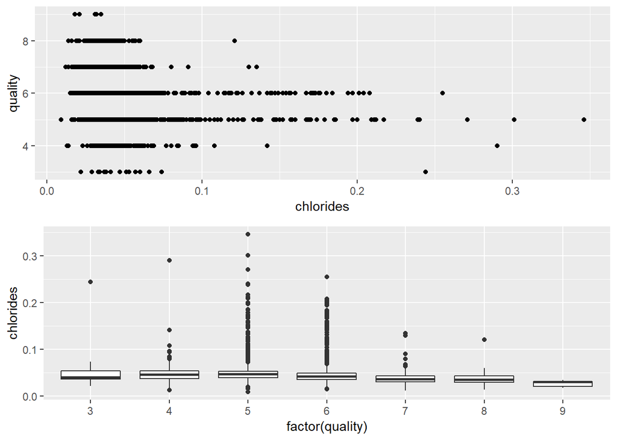

Ignoring the 99th percentile, revisit the plot:

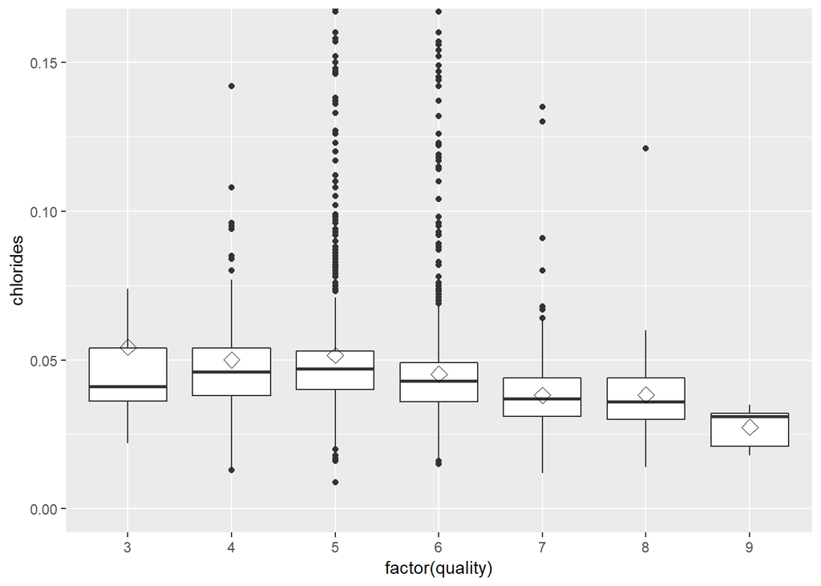

Summarize the chlorides and white wine Quality:

```
## quality: 3
##    Min. 1st Qu.  Median    Mean 3rd Qu.    Max.
## 0.02200 0.03625 0.04100 0.05430 0.05400 0.24400
## --------------------------------------------------------
## quality: 4
##    Min. 1st Qu.  Median    Mean 3rd Qu.    Max.
##  0.0130  0.0380  0.0460  0.0501  0.0540  0.2900
## --------------------------------------------------------
## quality: 5
##    Min. 1st Qu.  Median    Mean 3rd Qu.    Max.
## 0.00900 0.04000 0.04700 0.05155 0.05300 0.34600
## --------------------------------------------------------
## quality: 6
##    Min. 1st Qu.  Median    Mean 3rd Qu.    Max.
## 0.01500 0.03600 0.04300 0.04522 0.04900 0.25500
## --------------------------------------------------------
## quality: 7
##    Min. 1st Qu.  Median    Mean 3rd Qu.    Max.
## 0.01200 0.03100 0.03700 0.03819 0.04400 0.13500
## --------------------------------------------------------
## quality: 8
##    Min. 1st Qu.  Median    Mean 3rd Qu.    Max.
## 0.01400 0.03000 0.03600 0.03831 0.04400 0.12100
## --------------------------------------------------------
## quality: 9
##    Min. 1st Qu.  Median    Mean 3rd Qu.    Max.
##  0.0180  0.0210  0.0310  0.0274  0.0320  0.0350
```

From all these important variables, we have observed some trends but none of them significantly differentiate the low quality from high quality wine. Moving on to the next part - we can look how these important predictors are correlated

Plotting the predictors by ignoring top and bottom 1%

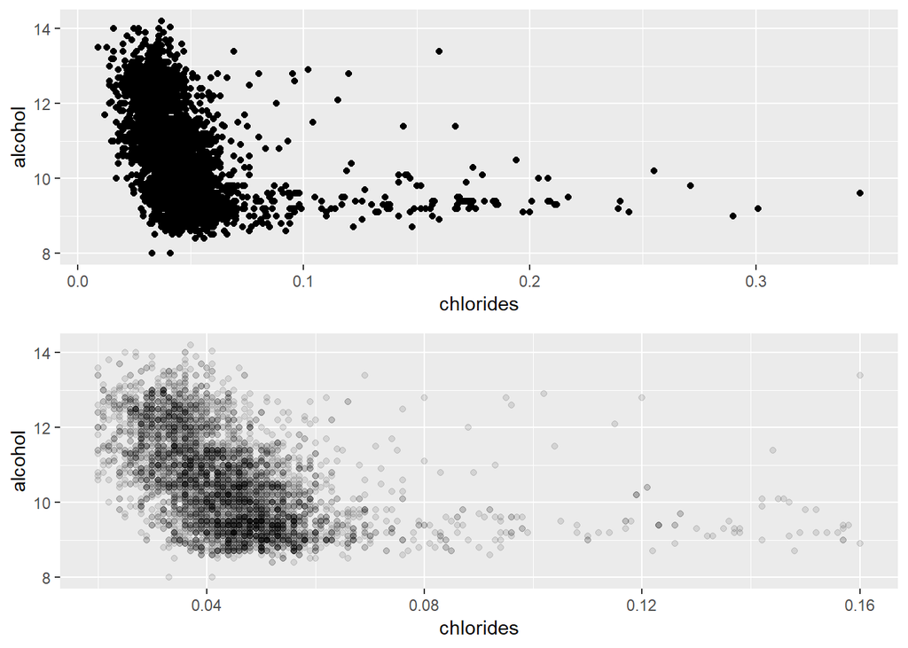

We can see that there is more alcohol in wines with less chlorides from the plots.Next we will plot the correlations among alcohol, chlorides and quality

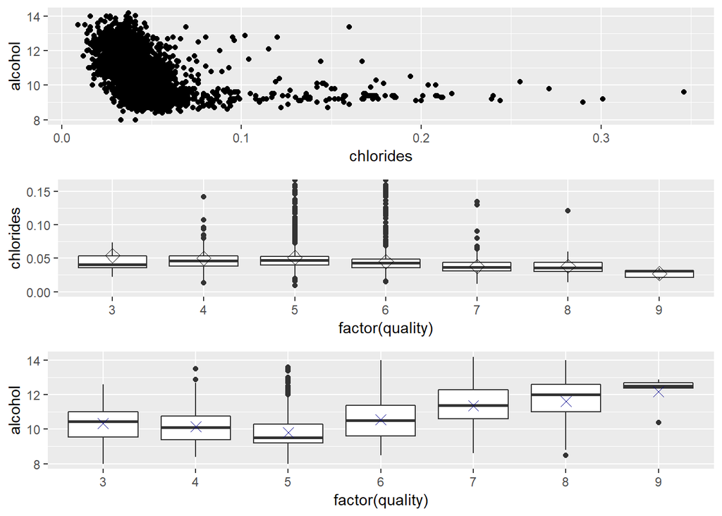

Next we will move on to density and alcohol:

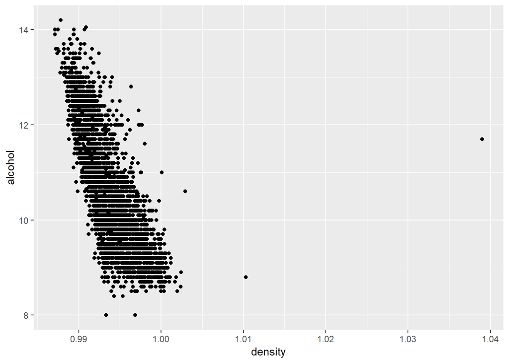

Now as we have observed a significant correlation, we will concentrate on the middle 98% of the data

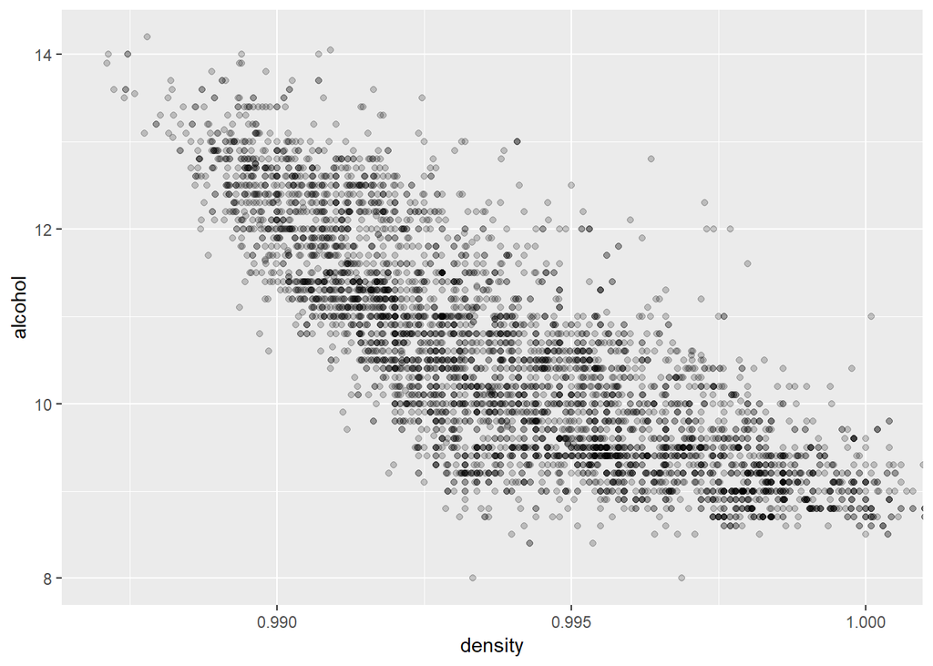

Next we will look into the correlation between other variables like residual sugar(I choose this as this has the skewedness in our previous plot) , total sulphur dioxide with the important wine quality predictor variables(from the above)

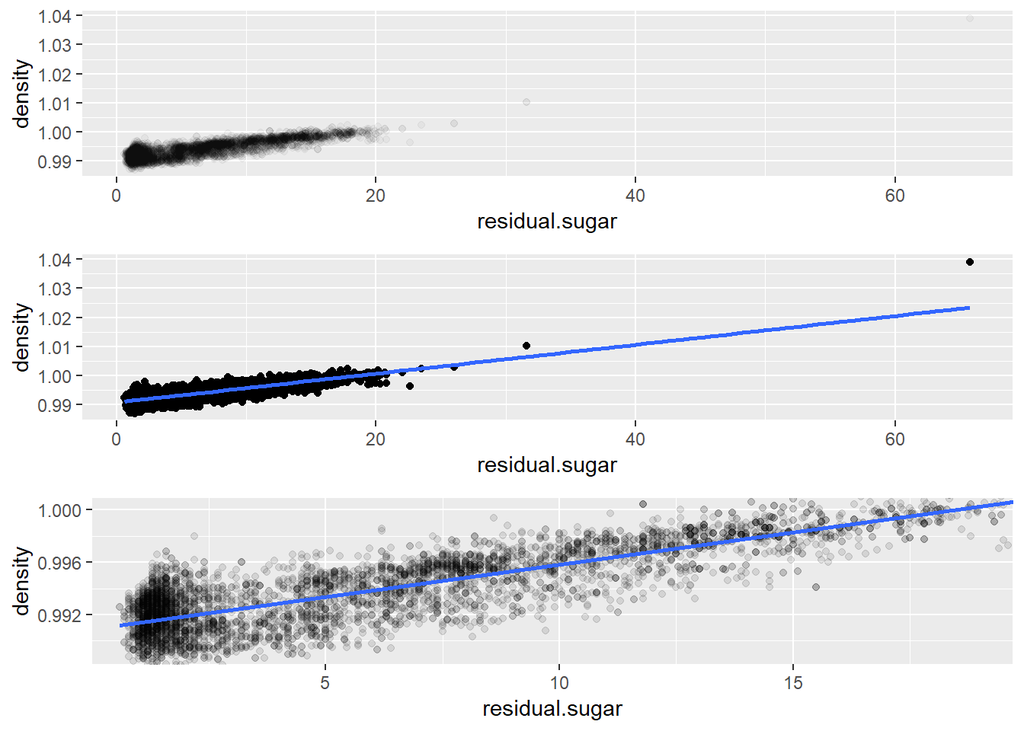

We observe from the above plot that the points with the highest amounts of residual sugar are also the more in density as well. We can move onto the residual sugar and alcohol next:

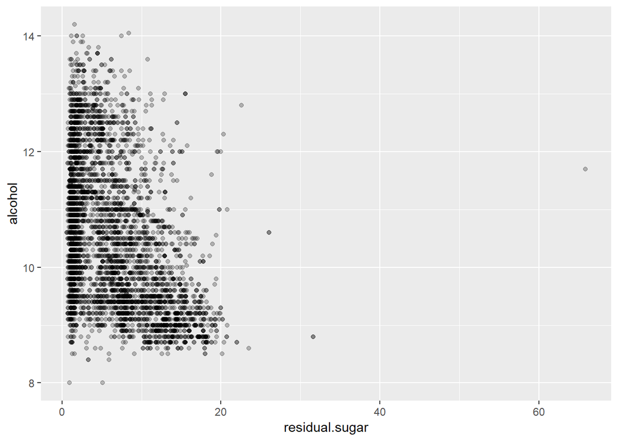

Next we can draw removing the outliers of the residual sugar:

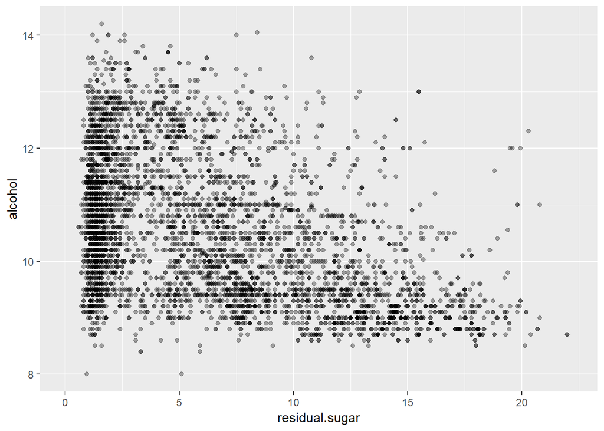

As nothing significant observations came out from this plot, I have moved onto logarithmic transformation of residual sugar.

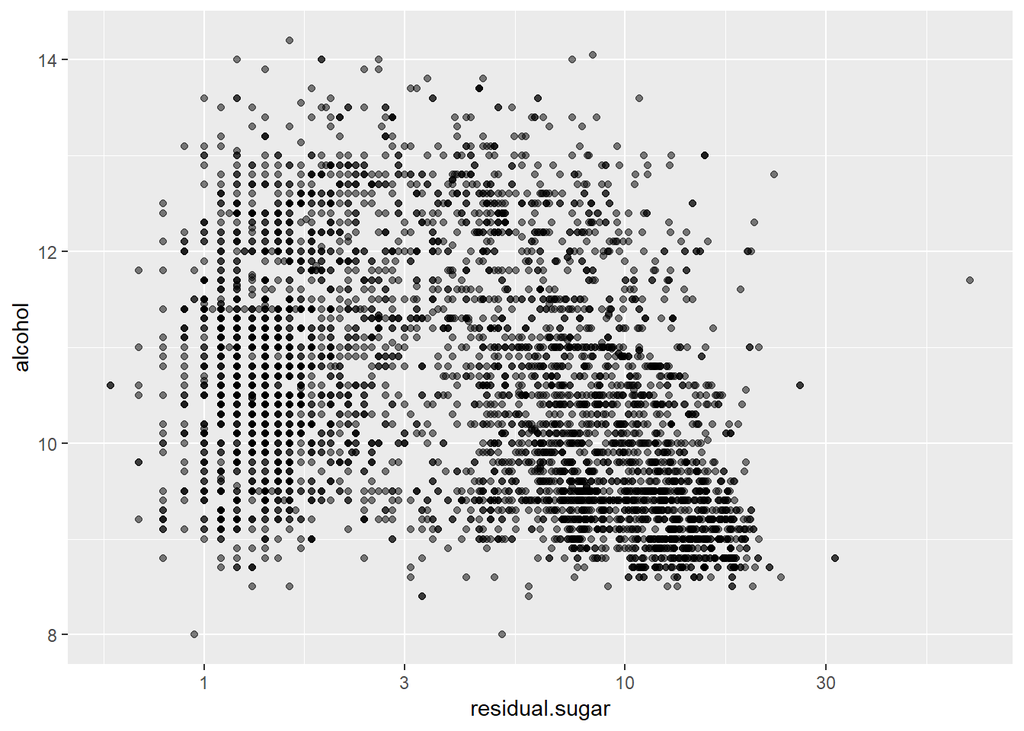

Unfortunately, nothing interesting came out , rather the previous linear plot was better to observe the trend.

We will move onto total sulphur dioxide next.

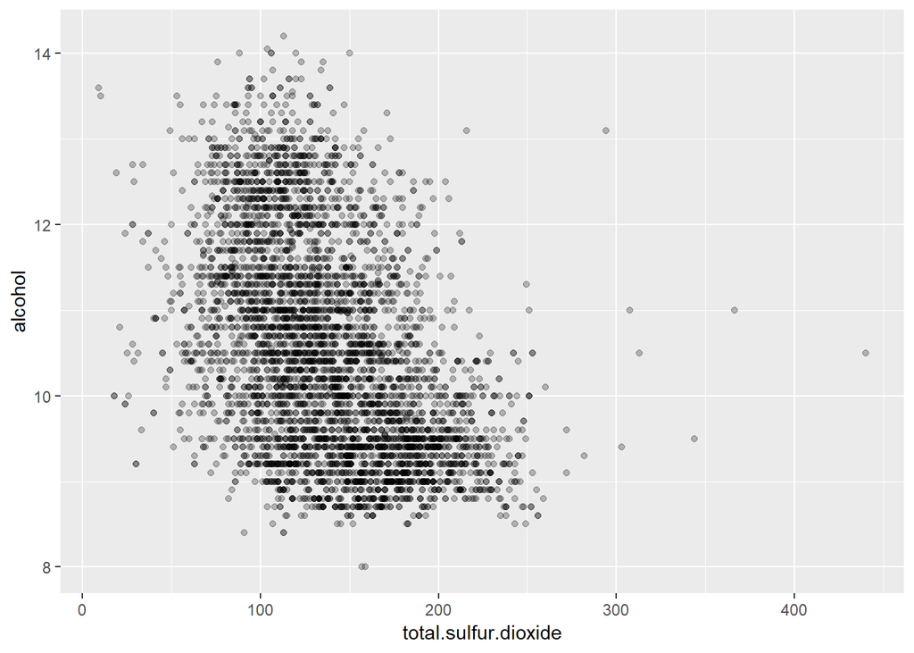

Now removing some of the outliers we will plot again considering the summary we have observed previously that we know total sulfur dioxide’s first and third quartile are 108 and 167 and also outlier means it is less than the (first quartile - 1.5 multiplied by InterquartileRange) or it is more than (1.5 multiplied by InterquartileRange + third quartile)

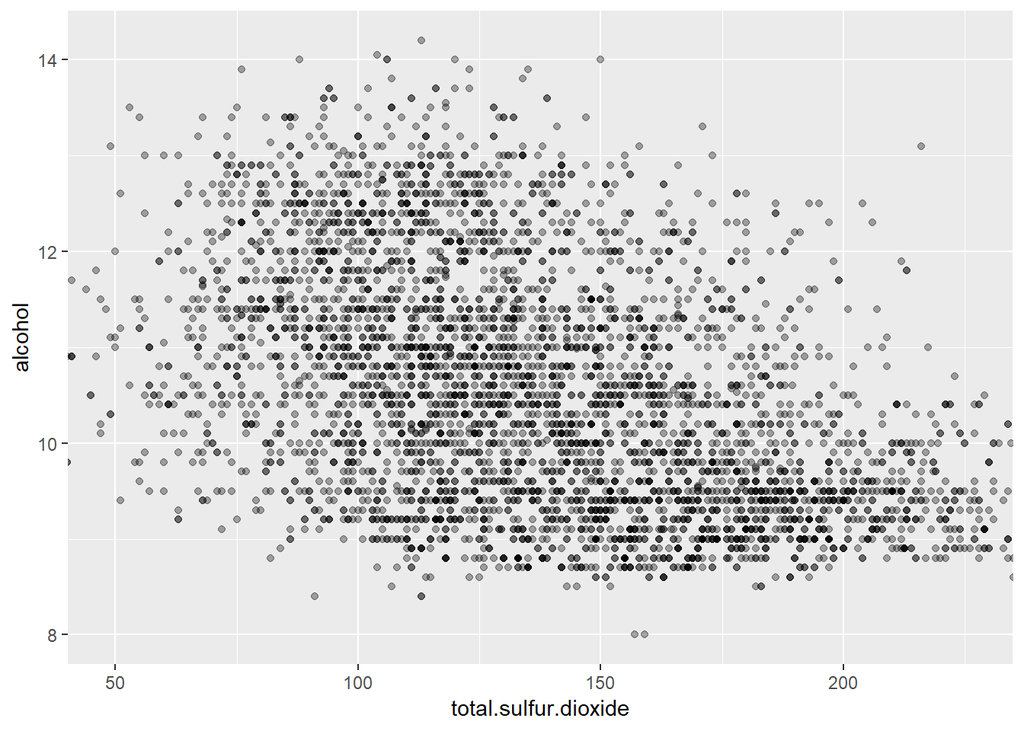

Not very distinct but there is little downward trend of alcohol and total sulfur dioxide in the above plot.

# Bivariate Analysis

### Talk about some of the relationships you observed in this part of the . How did the feature(s) of interest vary with other features in dataset?

The first few relationships I looked into are the important predictors - chlorides, density and alcohol compared with the quality. Chlorides and quality have a correlation coefficient of -0.314, density and quality have a correlation coefficient of -0.348, and alcohol and quality have a correlation coefficient of 0.440.For all of the above cases, the trend is distinct while comparing mid to high quality wines. But the low quality wines are somewhat not following the same trends.  
Also I have tried to summarize how the important quality predictors are related with eachother and also with the other variables (not among the important ones). We have observed that the less alcohol in the wine, the greater the variance in the amount of chlorides in the wine and greater the variance in the density of the wine.

### Did you observe any interesting relationships between the other features (not the main feature(s) of interest)?

While comparing the important predictors with the other variables in the dataset,I have considered residual sugar and also total sulphur dioxide.We have observed that in case of the residualsugar is increasing, the density of the wine also increases which is justified as sugar has higher density than alcohol.Also we have noticed that as the alcohol content of the wine decreases, the variation in the amount of the residual sugar of the wine increases.

### What was the strongest relationship you found?

I think the strongest relationship I have observed from all the plots above is between residual sugar and density( having correlation coefficient of 0.839).

# Multivariate Plots Section

As we are moving along to the multivariate section, we will check the previous plots which have already been plotted and also can add some other variable as well for better overall understanding of our white wine quality dataset.

First one , we will look into chlorides, alcohol and the quality of wine.

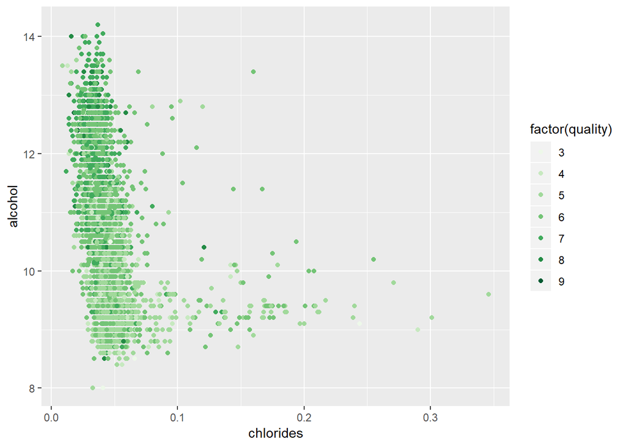

Now changing the quality with the buckets we have created before:

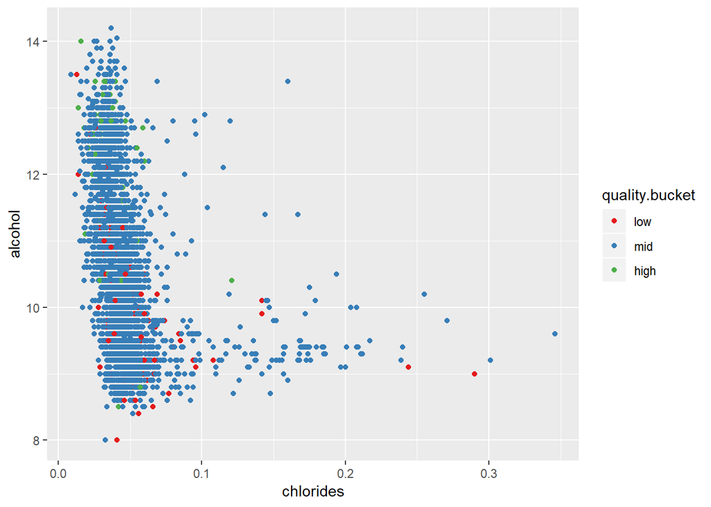

From the above plots , we have observed that not many low quality wines have high alcohol content. Also one ore thing to notice that not many high quality wines have low alcohol content and a high chloride content. To more detailed viewing , we can remove the quality with value 6 data.

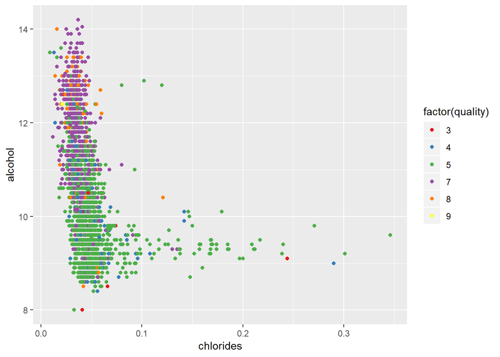

Now after we omit the wines with a quality rating of six, we can notice that there is a trend that the higher quality wines have higher alcohol content and smaller amounts of chlorides . The oppsite of this is visible for the lower quality wines.